# REGRESIÓN

Sergio Fernández, Miquel Ocón, Enrique Roa

14 de enero de 2023

# 1 REGRESIÓN DEL DATASET IRIS

La regresión lineal es un método estadístico para predecir la relación entre una variable dependiente (la que se quiere predecir) y una o más variables independientes que se usan para hacer la predicción.

## 1.1 OBJETIVO

El objetivo es realizar una regresión lineal (método estadístico para predecir la relación entre una variable dependiente con una o más variables independientes) del dataset **IRIS** el cual es es un conjunto de datos de muestra integrado por 150 muestras 50 muestras por tres especies de iris (Iris setosa, Iris virginica y Iris versicolor). Estas características se miden en centímetros y son el ancho y largo del sépalo y del pétalo.

## 1.2 LIBRERIAS

```r
library(caret)
library(leaps)
library(dplyr)
library(tidyr)
library(knitr)
library(readr)
library(ggplot2)
library(cowplot)
library(GGally)
library(plotrix)
library(ggcorrplot)
```

## 1.3 ANÁLISIS EXPLORATORIO INICIAL

```r
datos <- data.frame(iris)
head(datos)
```

```
##   Sepal.Length Sepal.Width Petal.Length Petal.Width Species
## 1          5.1         3.5          1.4         0.2  setosa
## 2          4.9         3.0          1.4         0.2  setosa
## 3          4.7         3.2          1.3         0.2  setosa
## 4          4.6         3.1          1.5         0.2  setosa
## 5          5.0         3.6          1.4         0.2  setosa
## 6          5.4         3.9          1.7         0.4  setosa
```

```r
dim(datos)
```

```
## [1] 150   5
```

```r
str(datos)
```

```
## 'data.frame':    150 obs. of  5 variables:
##  $ Sepal.Length: num  5.1 4.9 4.7 4.6 5 5.4 4.6 5 4.4 4.9 ...
##  $ Sepal.Width : num  3.5 3 3.2 3.1 3.6 3.9 3.4 3.4 2.9 3.1 ...
##  $ Petal.Length: num  1.4 1.4 1.3 1.5 1.4 1.7 1.4 1.5 1.4 1.5 ...
##  $ Petal.Width : num  0.2 0.2 0.2 0.2 0.2 0.4 0.3 0.2 0.2 0.1 ...
##  $ Species     : Factor w/ 3 levels "setosa","versicolor",..: 1 1 1 1 1 1 1 1 1 1 ...
```

```r
summary(datos)
```

```
##   Sepal.Length    Sepal.Width     Petal.Length    Petal.Width
##  Min.   :4.300   Min.   :2.000   Min.   :1.000   Min.   :0.100
##  1st Qu.:5.100   1st Qu.:2.800   1st Qu.:1.600   1st Qu.:0.300
##  Median :5.800   Median :3.000   Median :4.350   Median :1.300
##  Mean   :5.843   Mean   :3.057   Mean   :3.758   Mean   :1.199
##  3rd Qu.:6.400   3rd Qu.:3.300   3rd Qu.:5.100   3rd Qu.:1.800
##  Max.   :7.900   Max.   :4.400   Max.   :6.900   Max.   :2.500
##        Species
##  setosa    :50
##  versicolor:50
##  virginica :50
##
##
##
```

a primera vista observamos que el dataframe contiene:

- 150 observaciones
- 5 variables
- 1 variables cualitativas (la especie de iris)
- 4 variables cuantitativas
- No hay valores faltantes

## 1.4 DIVISIÓN TRAIN - TEST

Dividimos 70/30 %

```r
set.seed(123)
part <- createDataPartition(iris$Species, p = 0.7, list = FALSE)

d_train <- iris[part, ]
d_test <- iris[-part, ]
```

## 1.5 EDA

### 1.5.1 VARIABLES CUALITATIVAS

```r
table(d_train$Species)
```

```
##
##     setosa versicolor  virginica
##         35         35         35
```

### 1.5.2 VARIABLES CUANTITATIVAS

Pasamos a observar las variables cuantitativas.

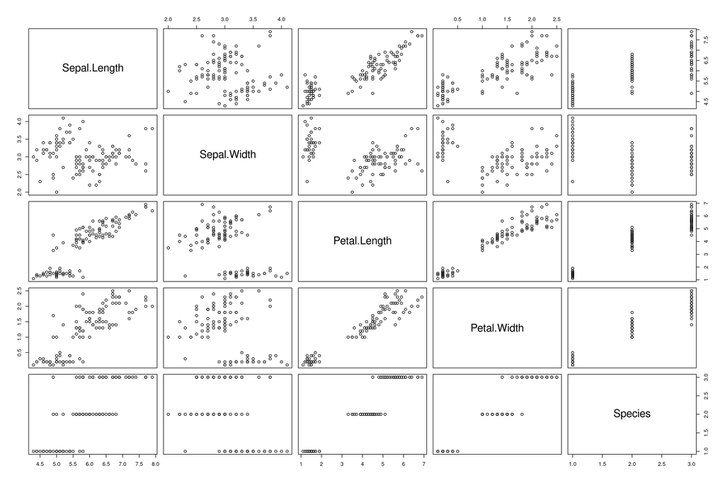

```r
pairs(d_train)
```

```r
cor(d_train[,1:4])
```

```
##              Sepal.Length Sepal.Width Petal.Length Petal.Width
## Sepal.Length    1.0000000  -0.0792996    0.8759879   0.8197900
## Sepal.Width    -0.0792996   1.0000000   -0.3851319  -0.3404203
## Petal.Length    0.8759879  -0.3851319    1.0000000   0.9624461
## Petal.Width     0.8197900  -0.3404203    0.9624461   1.0000000
```

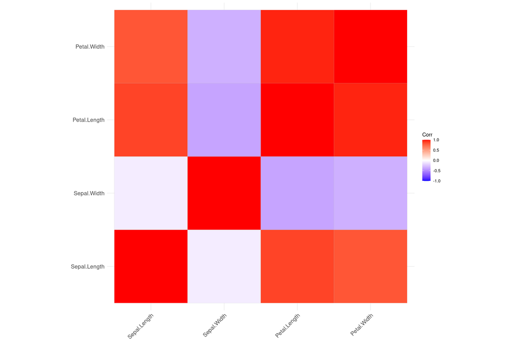

```r
n_data <- d_train [,1:4]
ggcorrplot(cor(n_data))
```

```r
mean(d_train$Petal.Length)
```

```
## [1] 3.775238
```

```r
sd(d_train$Petal.Length)
```

```
## [1] 1.775679
```

```r
var(d_train$Petal.Length)
```

```
## [1] 3.153035
```

## 1.6 MODELO REGRESIÓN

Utilizamos la longitud del petalo contra todas las otras variables. P valor menor que 0.05, R cuadrado y R cuadrado ajustado superiores al 0.9, modelo muy explicativo.

```r
reg_pl<-lm(Petal.Length~. , data = d_train)
summary(reg_pl)
```

```
##
## Call:
## lm(formula = Petal.Length ~ ., data = d_train)
##
## Residuals:
##      Min       1Q   Median       3Q      Max
## -0.76677 -0.16707  0.00297  0.16241  0.65722
##
## Coefficients:
##                   Estimate Std. Error t value Pr(>|t|)
## (Intercept)       -1.14547    0.32420  -3.533 0.000625 ***
## Sepal.Length       0.60273    0.06136   9.823 2.66e-16 ***
## Sepal.Width       -0.15026    0.09998  -1.503 0.136040
## Petal.Width        0.49326    0.14970   3.295 0.001366 **
## Speciesversicolor  1.58836    0.21006   7.562 2.06e-11 ***
## Speciesvirginica   2.18472    0.30074   7.264 8.70e-11 ***
## ---
## Signif. codes:  0 '***' 0.001 '**' 0.01 '*' 0.05 '.' 0.1 ' ' 1
##
## Residual standard error: 0.2696 on 99 degrees of freedom
## Multiple R-squared:  0.9781, Adjusted R-squared:  0.977
## F-statistic: 882.8 on 5 and 99 DF,  p-value: < 2.2e-16
```

Procedemos a hacer lo mismo contra las variables que nos aparecen correladas en este caso Sepal Length.

```r
reg_pl_2 <- lm(Petal.Length ~ Sepal.Length, data = d_train)
summary(reg_pl_2)
```

```
##
## Call:
## lm(formula = Petal.Length ~ Sepal.Length, data = d_train)
##
## Residuals:
##      Min       1Q   Median       3Q      Max
## -2.47407 -0.52578 -0.00551  0.52707  2.47422
##
## Coefficients:
##              Estimate Std. Error t value Pr(>|t|)
## (Intercept)  -6.94825    0.58782  -11.82   <2e-16 ***
## Sepal.Length  1.83144    0.09936   18.43   <2e-16 ***
## ---
## Signif. codes:  0 '***' 0.001 '**' 0.01 '*' 0.05 '.' 0.1 ' ' 1
##
## Residual standard error: 0.8606 on 103 degrees of freedom
## Multiple R-squared:  0.7674, Adjusted R-squared:  0.7651
## F-statistic: 339.7 on 1 and 103 DF,  p-value: < 2.2e-16
```

R cuadrado es 0.76 indica que el 76% de la variabilidad en la longitud del pétalo puede ser explicada por la variabilidad en la longitud del sépalo.

VERIFICACION RESIDUOS

Vamos a tratar de verificar silos residuos siguen una distribución normal

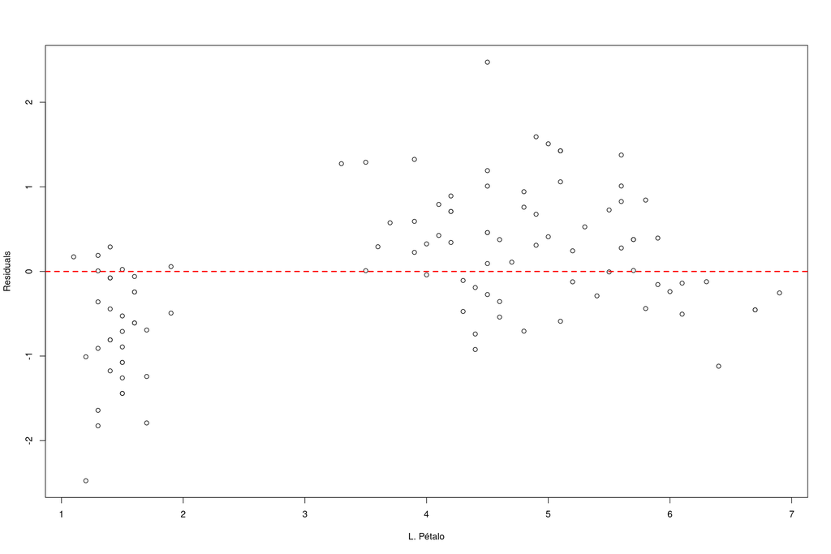

```r
plot(reg_pl_2$residuals ~ d_train$Petal.Length, xlab = "L. Pétalo", ylab = "Residuals")
abline(h = 0, col = "red", lwd = 2, lty = 2)
```

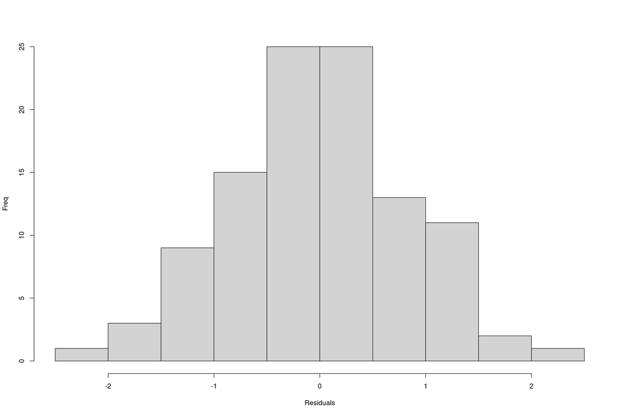

```r
hist(reg_pl_2$residuals, xlab = "Residuals", ylab = "Freq", main = "")
```

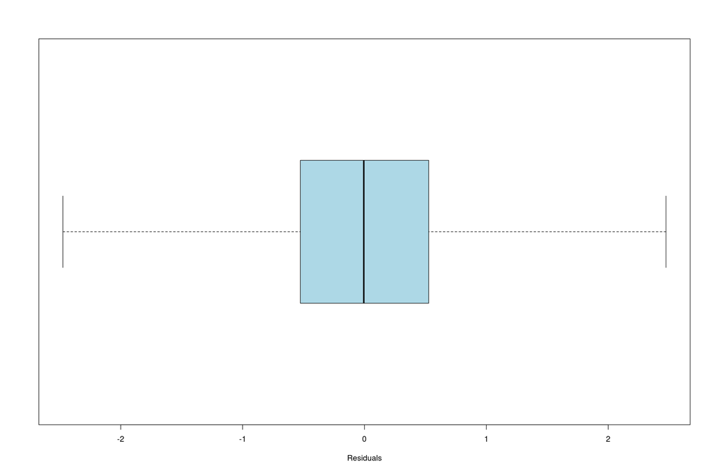

```r
boxplot(reg_pl_2$residuals, bty="l", range=2, col="lightblue", horizontal=T,xlab="Residuals")
```

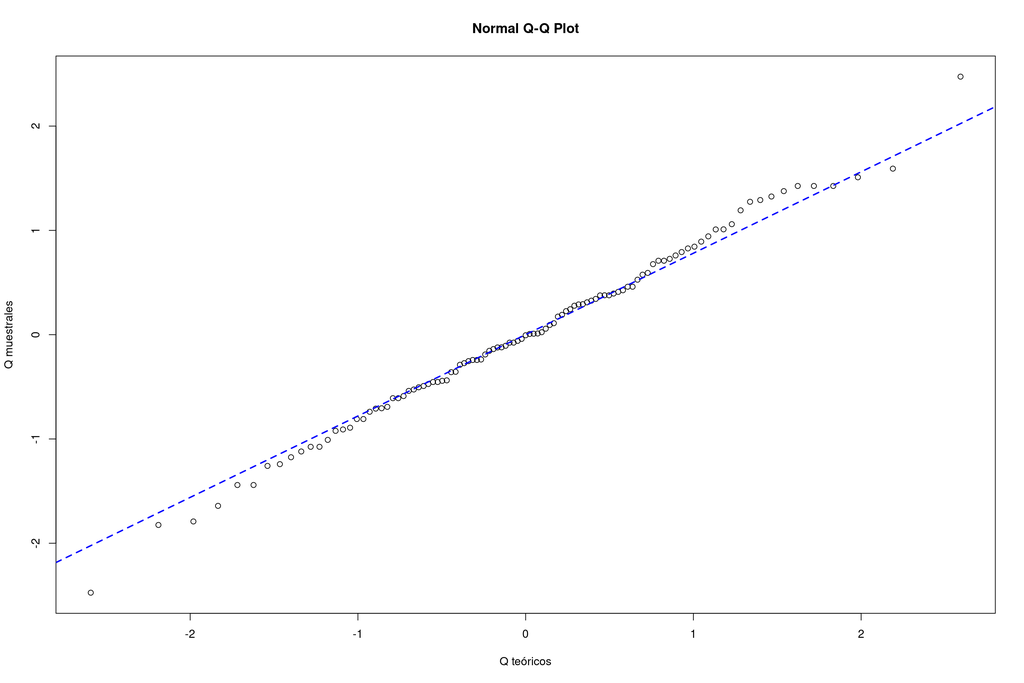

```r
qqnorm(reg_pl_2$residuals, xlab = "Q teóricos", ylab = "Q muestrales")
qqline(reg_pl_2$residuals, lwd = 2, lty = 2, col = "blue")
```

TECNICA SUPERVISADA FORWARD

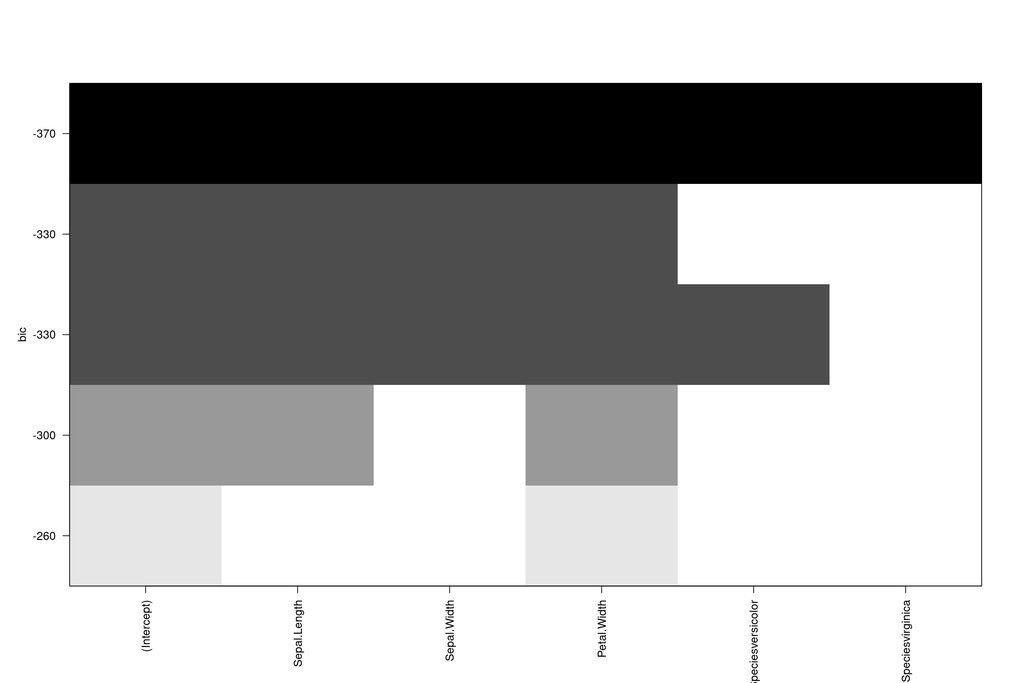

```r
mforward <- leaps::regsubsets(Petal.Length~. , data = d_train, method="forward")
plot(mforward)
```

# 2 BACKTESTING

Ahora analizamos test y usamos el modelo.

```r
summary(d_test)
```

```
##   Sepal.Length    Sepal.Width     Petal.Length    Petal.Width
##  Min.   :4.400   Min.   :2.200   Min.   :1.000   Min.   :0.100
##  1st Qu.:5.100   1st Qu.:2.800   1st Qu.:1.500   1st Qu.:0.400
##  Median :5.700   Median :3.000   Median :4.400   Median :1.300
##  Mean   :5.816   Mean   :3.093   Mean   :3.718   Mean   :1.202
##  3rd Qu.:6.300   3rd Qu.:3.400   3rd Qu.:5.100   3rd Qu.:1.800
##  Max.   :7.700   Max.   :4.400   Max.   :6.600   Max.   :2.500
##        Species
##  setosa    :15
##  versicolor:15
##  virginica :15
##
##
##
```

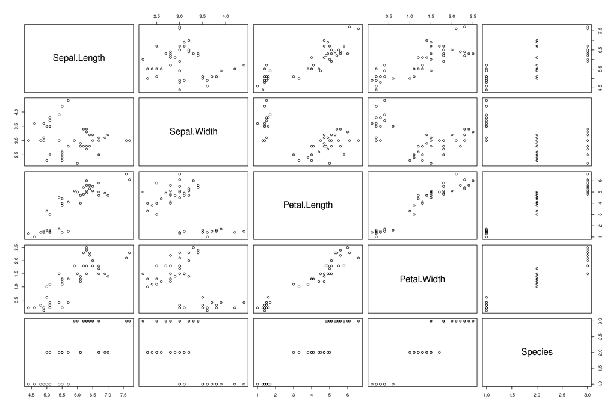

```r
pairs(d_test)
```

```r
cor(d_test[,1:4])
```

```
##              Sepal.Length Sepal.Width Petal.Length Petal.Width
## Sepal.Length    1.0000000  -0.1980296    0.8623017   0.8148517
## Sepal.Width    -0.1980296   1.0000000   -0.5189345  -0.4254296
## Petal.Length    0.8623017  -0.5189345    1.0000000   0.9645019
## Petal.Width     0.8148517  -0.4254296    0.9645019   1.0000000
```

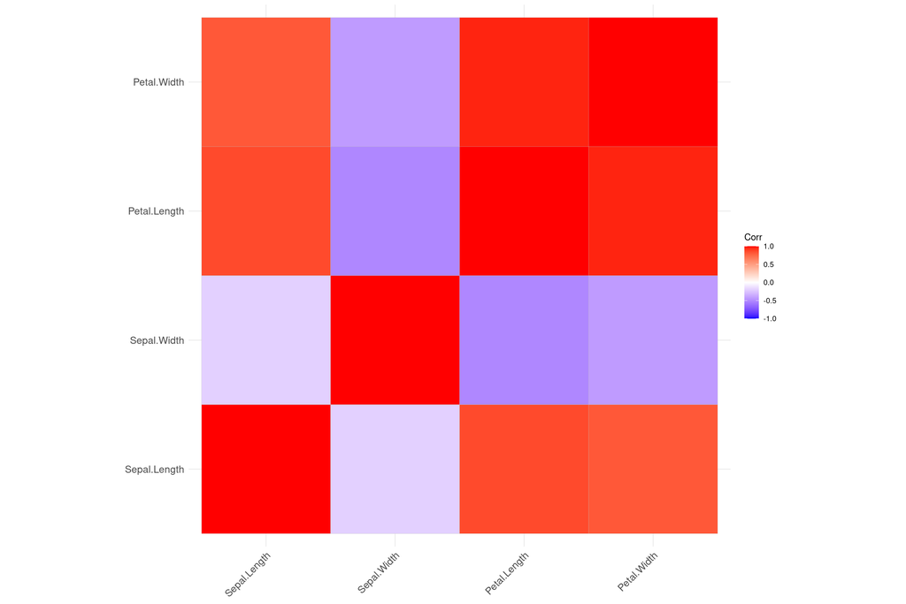

```r
n_data <- d_test [,1:4]
ggcorrplot(cor(n_data))
```

```r
mean(d_test$Petal.Length)
```

```
## [1] 3.717778
```

```r
sd(d_test$Petal.Length)
```

```
## [1] 1.760073
```

```r
var(d_test$Petal.Length)
```

```
## [1] 3.097859
```

## 2.1 CROSS VALIDATION

Hacemos validación cruzada, partimos el dataset en 4 partes y probamos el modelo.

```r
cross_control <- trainControl(method="cv",number=4,verboseIter = TRUE)
```

```r
reg_pl_3 <- train(Petal.Length ~ Sepal.Length, data = d_train, method="lm",trControl=cross_control)
reg_pl_3
```

```
## Linear Regression
##
## 105 samples
##   1 predictor
##
## No pre-processing
## Resampling: Cross-Validated (4 fold)
## Summary of sample sizes: 80, 79, 78, 78
## Resampling results:
##
##   RMSE       Rsquared   MAE
##   0.8503786  0.7655464  0.6782602
##
## Tuning parameter 'intercept' was held constant at a value of TRUE
```

```r
summary(reg_pl_3)
```

```
##
## Call:
## lm(formula = .outcome ~ ., data = dat)
##
## Residuals:
##      Min       1Q   Median       3Q      Max
## -2.47407 -0.52578 -0.00551  0.52707  2.47422
##
## Coefficients:
##              Estimate Std. Error t value Pr(>|t|)
## (Intercept)  -6.94825    0.58782  -11.82   <2e-16 ***
## Sepal.Length  1.83144    0.09936   18.43   <2e-16 ***
## ---
## Signif. codes:  0 '***' 0.001 '**' 0.01 '*' 0.05 '.' 0.1 ' ' 1
##
## Residual standard error: 0.8606 on 103 degrees of freedom
## Multiple R-squared:  0.7674, Adjusted R-squared:  0.7651
## F-statistic: 339.7 on 1 and 103 DF,  p-value: < 2.2e-16
```

Comparando vemos que ambos modelos son parecidos.